# Trực quan hóa dữ liệu với ggplot2

[Khoa học dữ liệu với R](https://svcuong.github.io/)

Cuong Sai

# 1 Giới thiệu gói ggplot2

Trực quan hóa dữ liệu (`data visualization`) là một trong những bước quan trọng và không thể thiếu trong khoa học dữ liệu. Nó là công cụ hiệu quả nhất giúp nhanh chóng diễn giải dữ liệu thô thành các thông tin có ích dưới dạng các biểu đồ.

Trong tutorial này, tôi xin giới thiệu với các bạn gói `ggplot2` trong `R` và ứng dụng nó để tạo các dạng biểu đồ thường gặp nhất trong khoa học dữ liệu.

**ggplot2** là một gói đồ họa rất mạnh dựa trên nguyên lý ngữ pháp biểu đồ (grammar ò graphics) và được phát triển bởi Hadley Wickham. Nó tuân theo cách tiếp cận nhiều lớp để cung cấp cho các ô nhìn tốt hơn với chức năng mạnh mẽ.

```
Plot = data + Aesthetics + Geometry
```

**Trong đó:**

- Lớp dữ liệu (`data`): Tập dữ liệu ở dạng `dataframe`
- Lớp thẩm mỹ (`Aesthetics`): sử dụng để quy định các biến cho trục Ox và Oy. Ngoài ra có thể sử dụng để điều chỉnh màu, kích cỡ, hình dạng,… của biểu đồ.
- Lớp Geometry: Thiết lập kiểu biểu đồ mà cần thể hiện (như histogram, box plot, line plot, density plot, dot plot,..)

**Ngoài ra có thể thêm các lớp không bắt buộc như:**

- Tính toán thống kê (statítical transformation): Sử dụng các tính toán trong biểu đồ. VD: Thêm các biểu đồ xu hướng dạng trơ (geom_smooth) , số lượng bin trong histogram… Lớp này có thể nằm lồng trong các lớp khác)
- Tỷ lệ (scale): Xác định tỷ lệ trong biểu đồ
- Trục tọa độ (Coordinate): Xác định hệ trục tọa độ vẽ biểu đồ. VD: Hệ tọa độ 3 trục trong không gian (hệ tọa đồ Descartes), hệ tọa độ cực
- Hệ thống Facet (tạm dịch: cách thức sắp xếp số liệu trên cùng 1 biểu đồ): Xác định cách thức sắp xếp vị trí của nhiều biểu đồ trên cùng một màn hình.
- Các yêu tố khác: Tên biểu đồ, tên trục, chú giải,

**Hai hàm chính được sử dụng để tạo biểu đồ trong ggplot2 là:

- `qplot()`: Hàm tạo biểu đồ nhanh, dễ sử dụng dành cho các biểu đồ đơn giản
- `qqplot()`: Hàm linh hoạt và mạnh mẽ hơn `qplot()` để xây dựng biểu đồ bằng các lớp chồng lên nhau.

**cài đặt và load ggplot2:**

```r
# Installation
install.packages('ggplot2')
# Loading
library(ggplot2)
```

Nếu các bạn đã biết sử dụng các biểu đồ base trên R thì ở bài này sẽ từng bước so sánh giữa base graphics với ggplot2, từ đó giúp bạn chuyển dần sang sử dụng ggplot2 một cách hiệu quả nhất.

[ggplot cheatsheet](https://rstudio.com/wp-content/uploads/2016/03/ggplot2-cheatsheet-2.0-Vietnamese.pdf)

# 2 Biểu đồ đường (Line graph)

`Line graph` là biểu đồ trong đó chứa một hoặc nhiều đường, một đường biểu diễn cho sự thay đổi của 1 yếu tố nào đó qua nhiều mốc thời gian (tuần, tháng, năm …).

## 2.1 Tạo line graph cơ bản

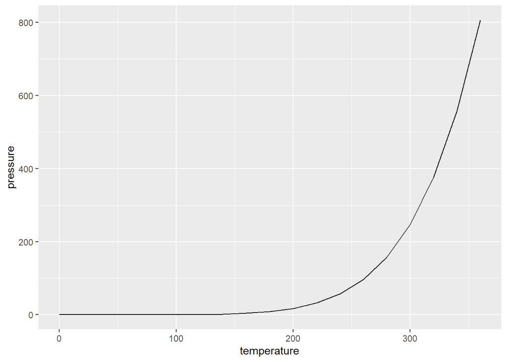

```r
library(ggplot2)
df <- pressure
ggplot(df, aes(x=temperature, y=pressure)) + geom_line()
```

## 2.2 Adding Points to a Line Graph

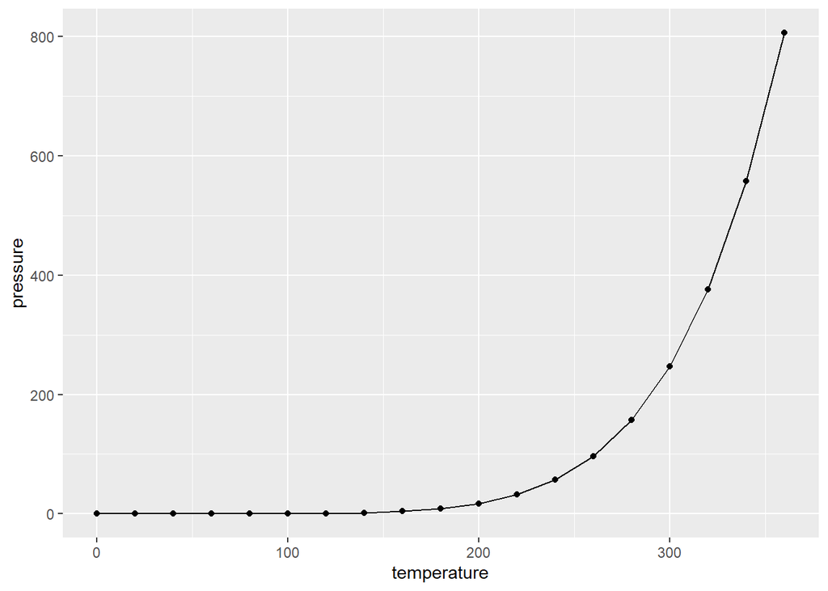

```r
ggplot(df, aes(x=temperature, y=pressure)) + geom_line() + geom_point()
```

## 2.3 Log axis

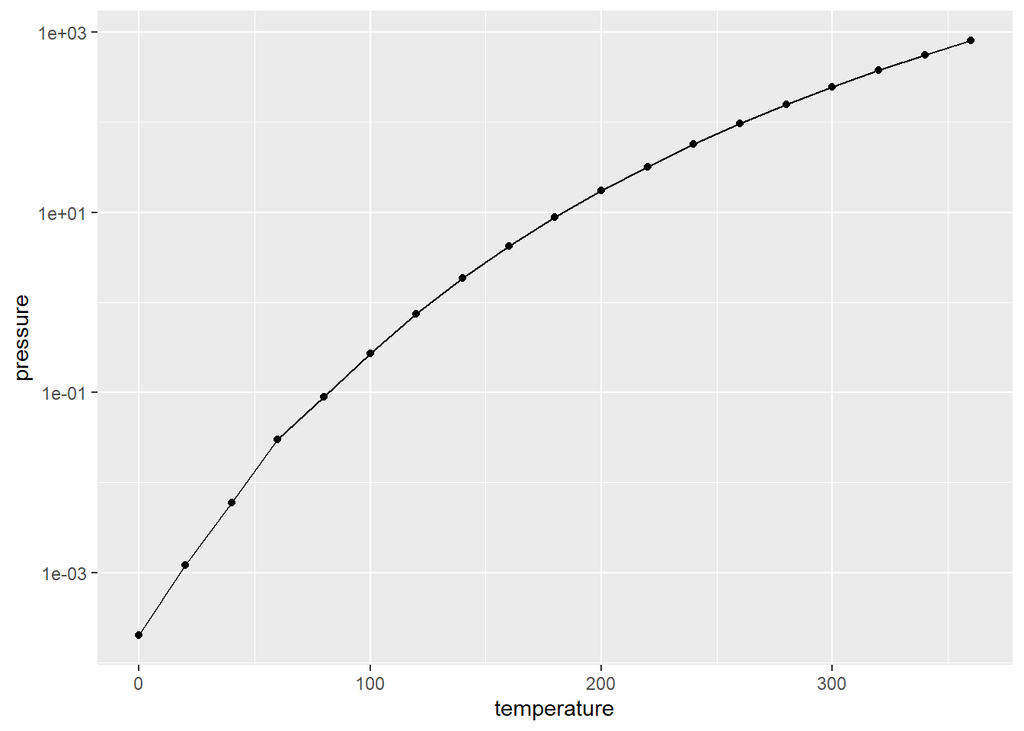

```r
ggplot(df, aes(x=temperature, y=pressure)) + geom_line() + geom_point() + scale_y_log10()
```

## 2.4 Changing the Appearance of Lines

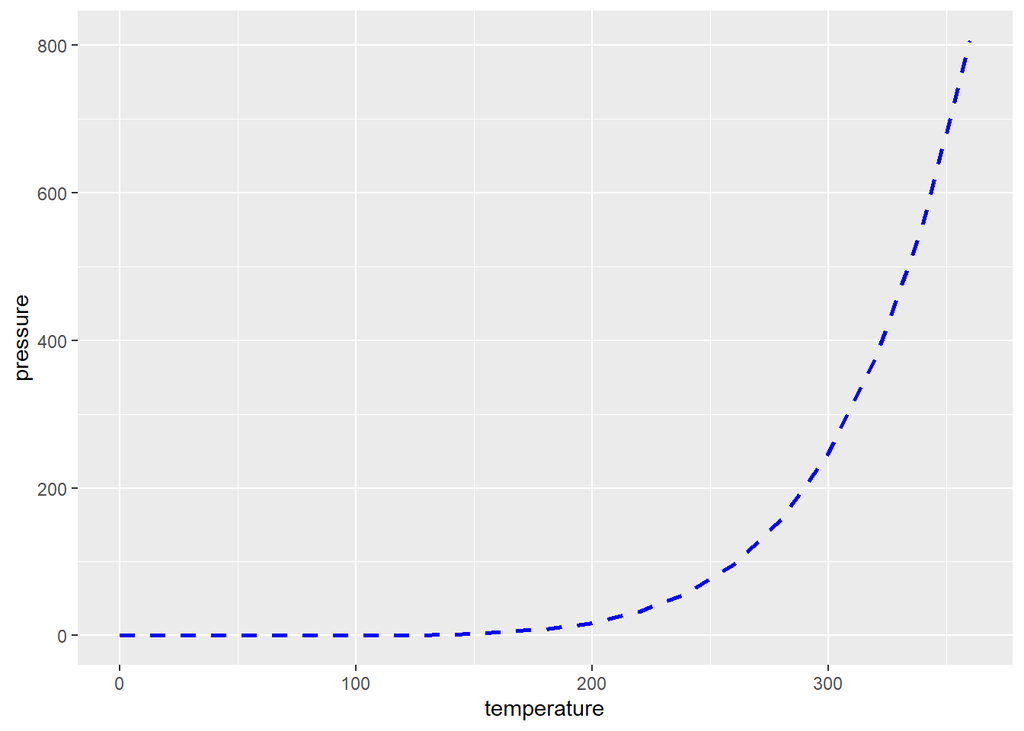

```r
ggplot(df, aes(x=temperature, y=pressure)) + geom_line(linetype="dashed", size=1, colour="blue")
```

## 2.5 Changing the Appearance of Points

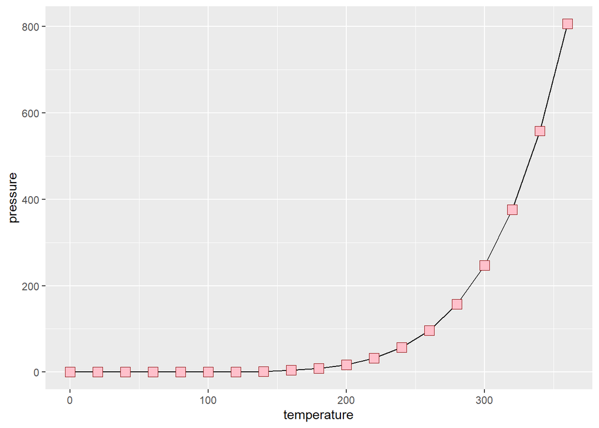

```r
ggplot(df, aes(x=temperature, y=pressure)) + geom_line() + geom_point(size=4, shape=22, colour="darkred", fill="pink")
```

## 2.6 Making a Line Graph with Multiple Lines

```r
library(dplyr)
nmonths = 24
x = seq(as.Date("2015/1/1"), by = "month", length.out = nmonths)
df1 <- data.frame(dates = x,Variable = rnorm(mean = 0.75,nmonths))
df2 <- data.frame(dates = x,Variable = rnorm(mean = -0.75,nmonths))
df3 <- data.frame(dates = x,Variable = rnorm(mean = 0.3,nmonths))
df <- df1 %>%  mutate(cat = "A") %>%  bind_rows(df2 %>% mutate(cat = "B")) %>%  bind_rows(df3 %>% mutate(cat = "C"))
head(df)
```

```
##        dates  Variable cat
## 1 2015-01-01 2.0714071   A
## 2 2015-02-01 0.1298262   A
## 3 2015-03-01 1.8972258   A
## 4 2015-04-01 0.8222482   A
## 5 2015-05-01 0.6745376   A
## 6 2015-06-01 1.1410323   A
```

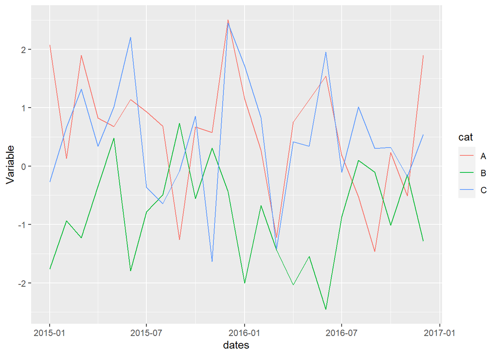

```r
# Tạo multiple lines graphs
ggplot(df, aes(x = dates, y = Variable, color = cat)) +  geom_line()
```

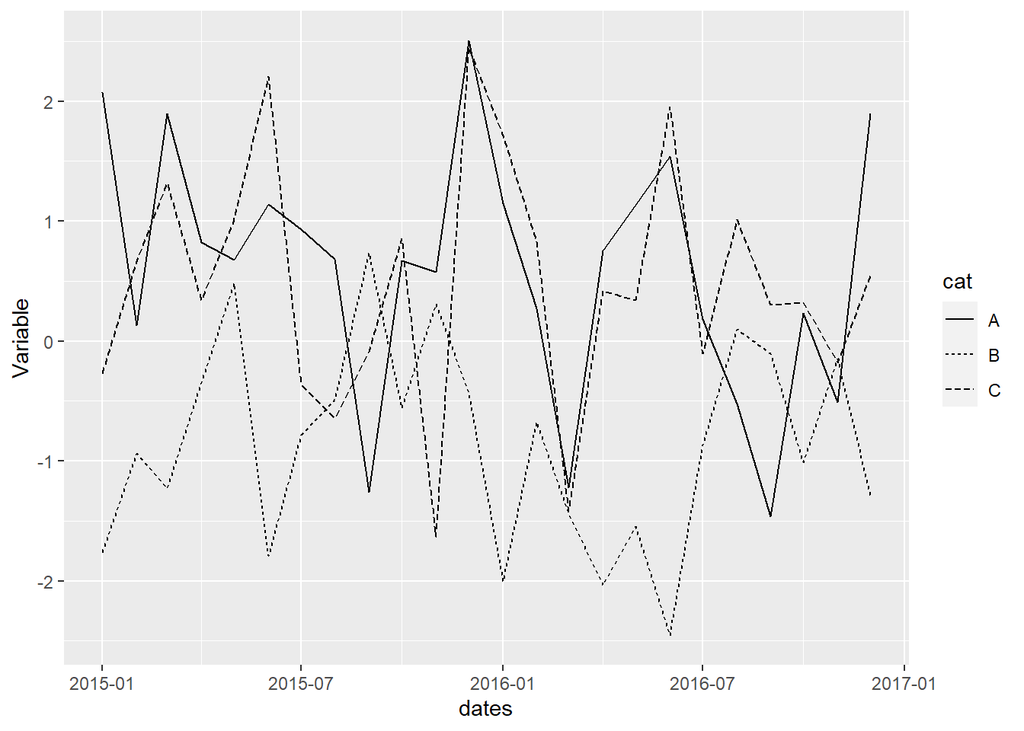

```r
ggplot(df, aes(x = dates, y = Variable, linetype = cat)) +  geom_line()
```

## 2.7 Making a Graph with a Shaded Area

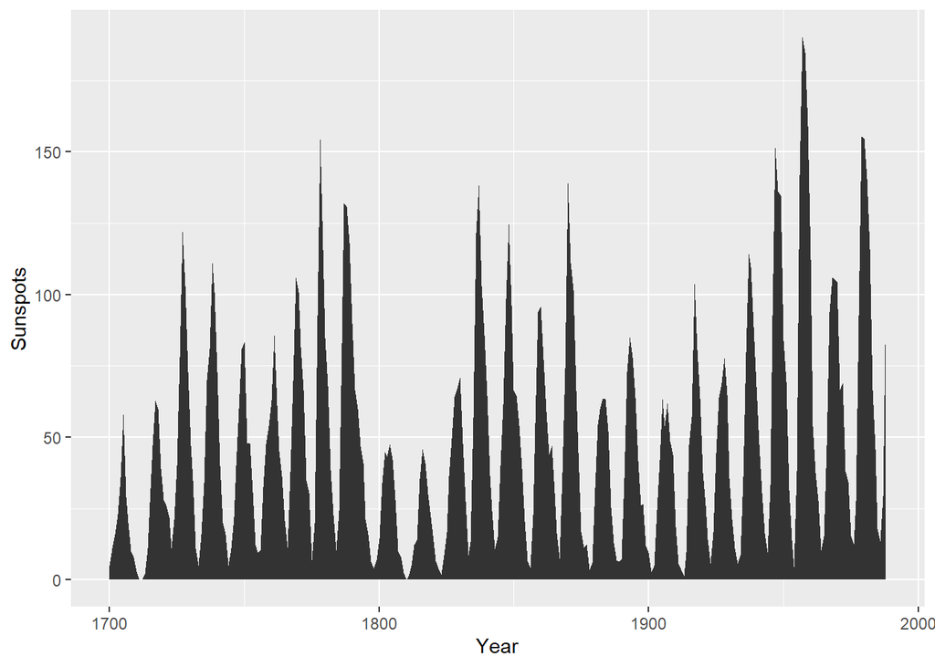

```r
# Convert the sunspot.year data set into a data frame for this example
sunspotyear <- data.frame(
Year = as.numeric(time(sunspot.year)),
Sunspots = as.numeric(sunspot.year)
)
ggplot(sunspotyear, aes(x=Year, y=Sunspots)) + geom_area()
```

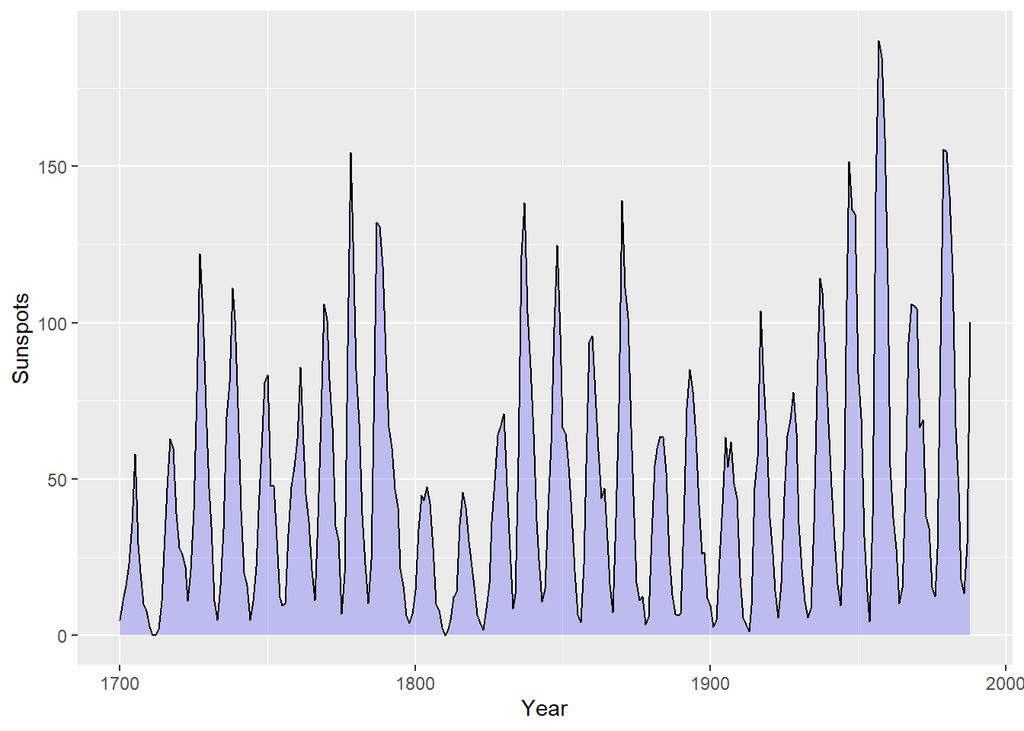

```r
ggplot(sunspotyear, aes(x=Year, y=Sunspots)) +
geom_area(colour="black", fill="blue", alpha=.2)
```

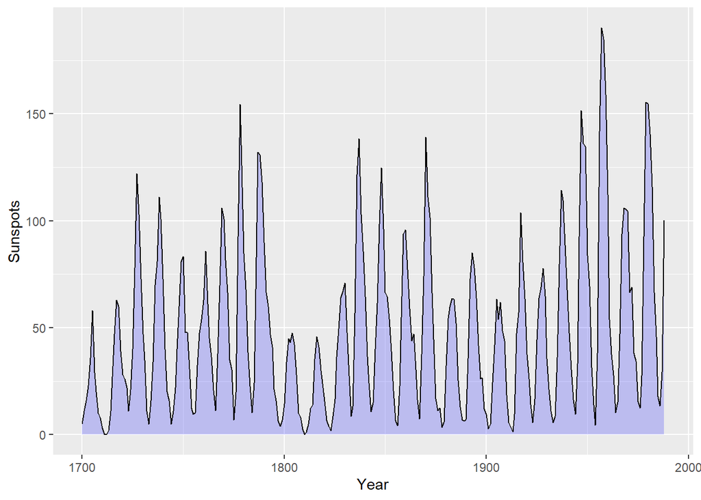

```r
ggplot(sunspotyear, aes(x=Year, y=Sunspots)) +
geom_area(fill="blue", alpha=.2) +
geom_line()
```

## 2.8 Making a Stacked Area Graph

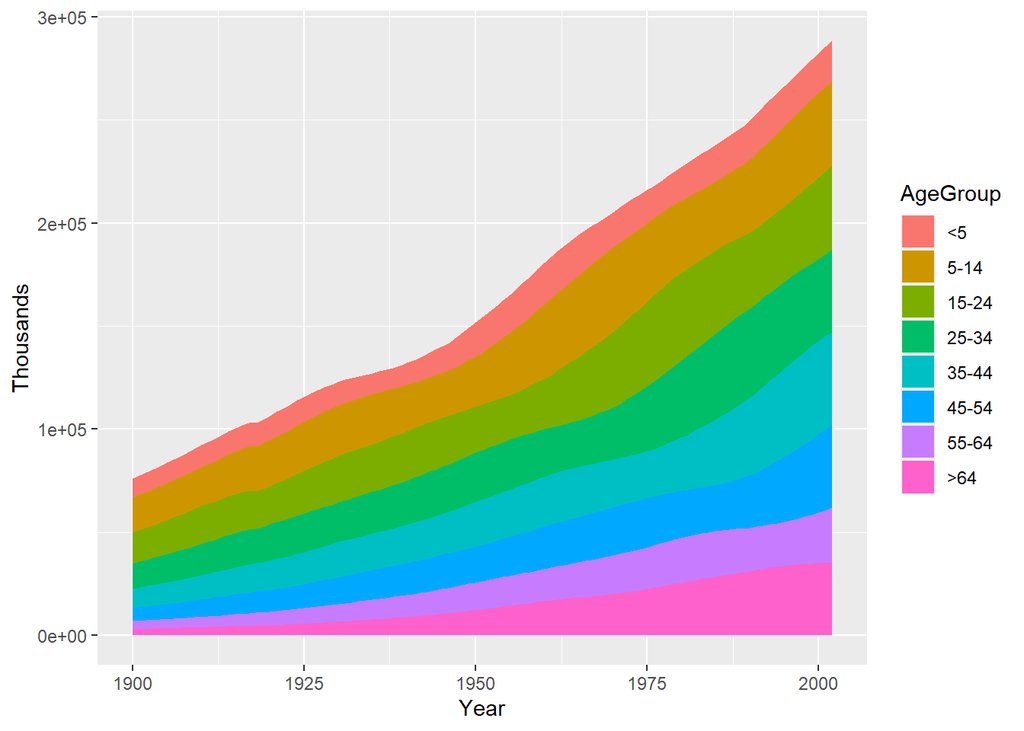

```r
library(gcookbook) # For the data set
ggplot(uspopage, aes(x=Year, y=Thousands, fill=AgeGroup)) + geom_area()
```

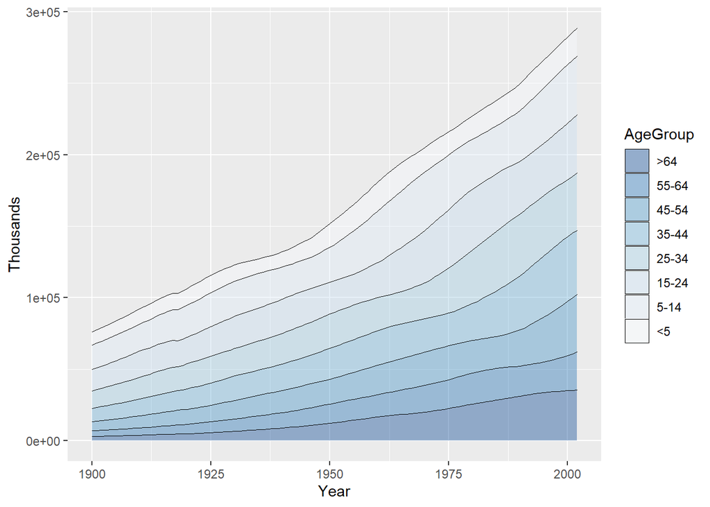

```r
ggplot(uspopage, aes(x=Year, y=Thousands, fill=AgeGroup)) +
geom_area(colour="black", size=.2, alpha=.4) +
scale_fill_brewer(palette="Blues", breaks=rev(levels(uspopage$AgeGroup)))
```

## 2.9 Making a Proportional Stacked Area Graph

```r
library(gcookbook) # For the data set
library(plyr) # For the ddply() function
# Convert Thousands to Percent
uspopage_prop <- ddply(uspopage, "Year", transform,
Percent = Thousands / sum(Thousands) * 100)
```

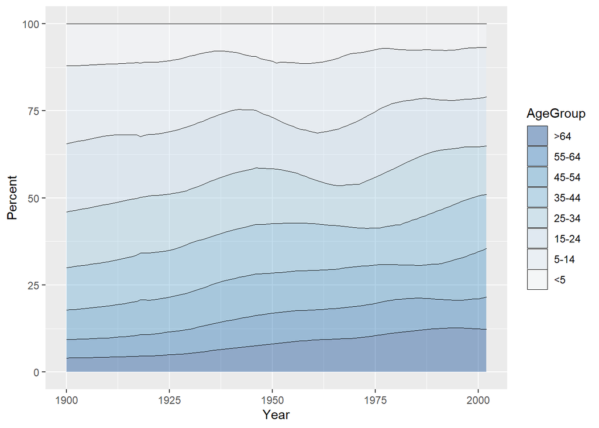

```r
ggplot(uspopage_prop, aes(x=Year, y=Percent, fill=AgeGroup)) +
geom_area(colour="black", size=.2, alpha=.4) +
scale_fill_brewer(palette="Blues", breaks=rev(levels(uspopage$AgeGroup)))
```

## 2.10 Adding a Confidence Region

```r
library(gcookbook) # For the data set
# Grab a subset of the climate data
clim <- subset(climate, Source == "Berkeley", select=c("Year", "Anomaly10y", "Unc10y"))
```

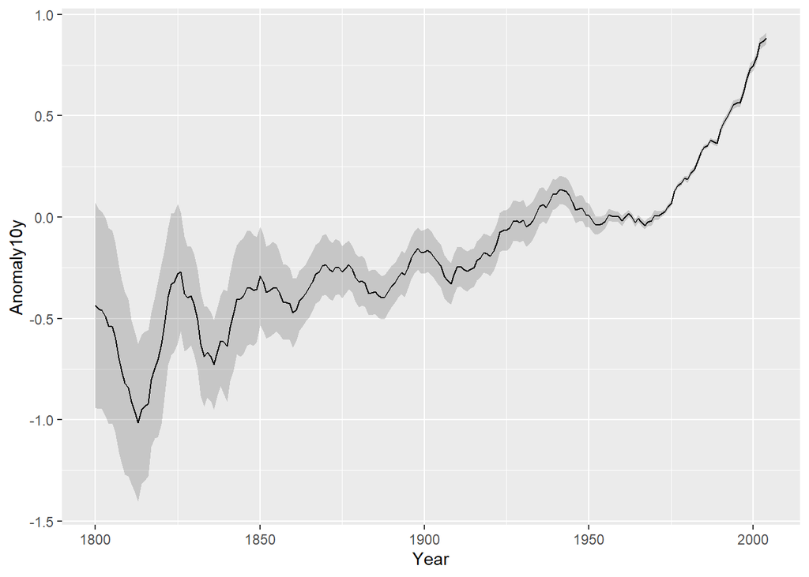

```r
# Shaded region
ggplot(clim, aes(x=Year, y=Anomaly10y)) +
geom_ribbon(aes(ymin=Anomaly10y-Unc10y, ymax=Anomaly10y+Unc10y),
alpha=0.2) +
geom_line()
```

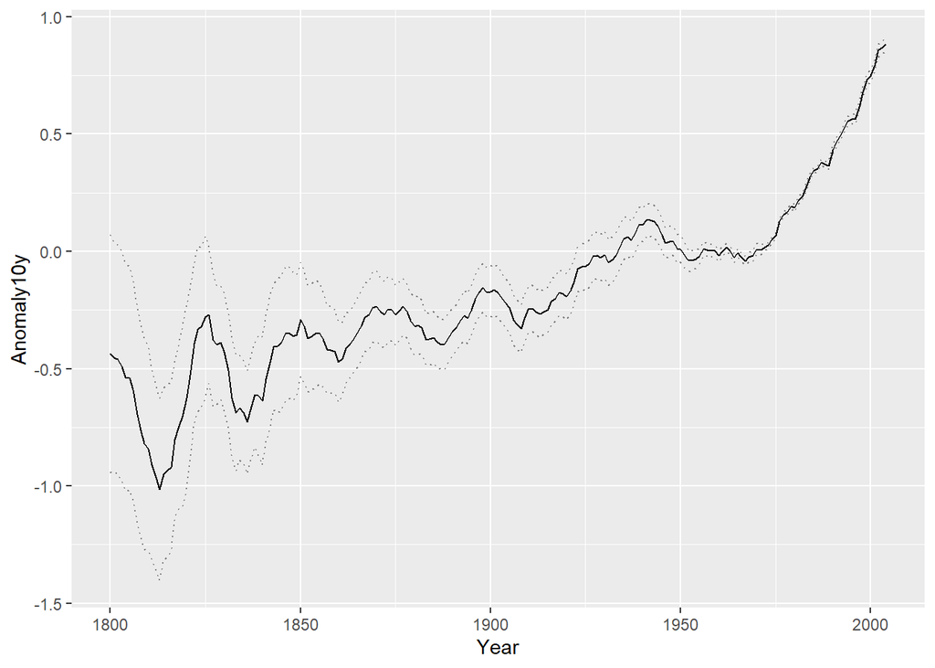

```r
# With a dotted line for upper and lower bounds
ggplot(clim, aes(x=Year, y=Anomaly10y)) +
geom_line(aes(y=Anomaly10y-Unc10y), colour="grey50", linetype="dotted") +
geom_line(aes(y=Anomaly10y+Unc10y), colour="grey50", linetype="dotted") +
geom_line()
```

# 3 Bar Graphs

## 3.1 Making a Basic Bar Graph

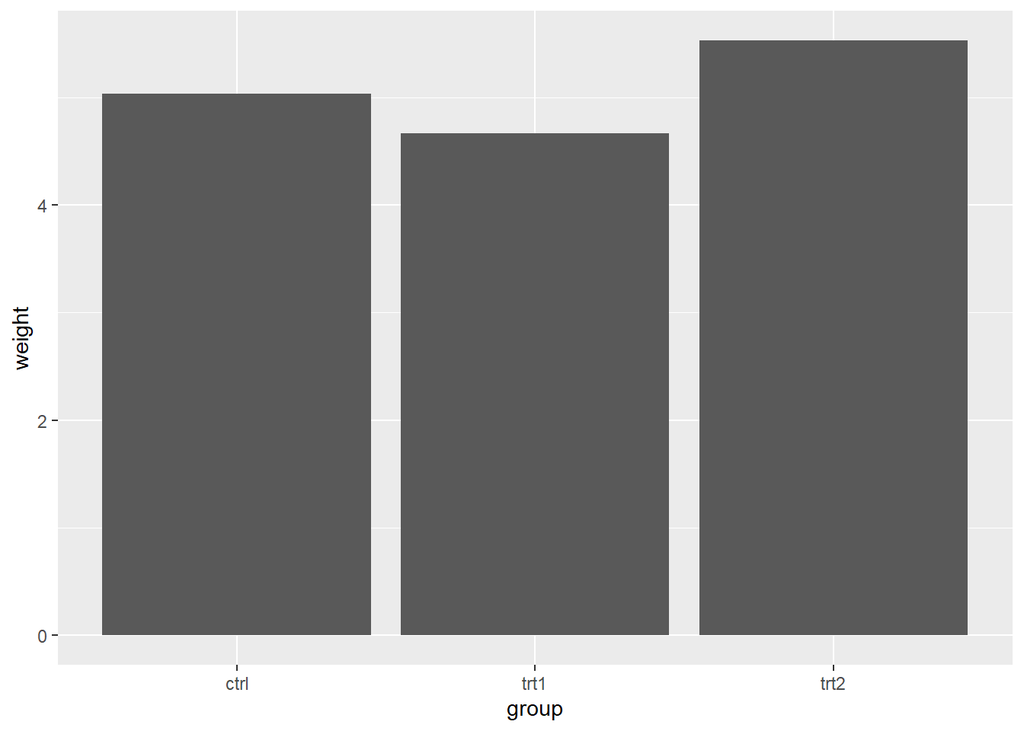

```r
library(gcookbook) # For the data set
ggplot(pg_mean, aes(x=group, y=weight)) + geom_bar(stat="identity")
```

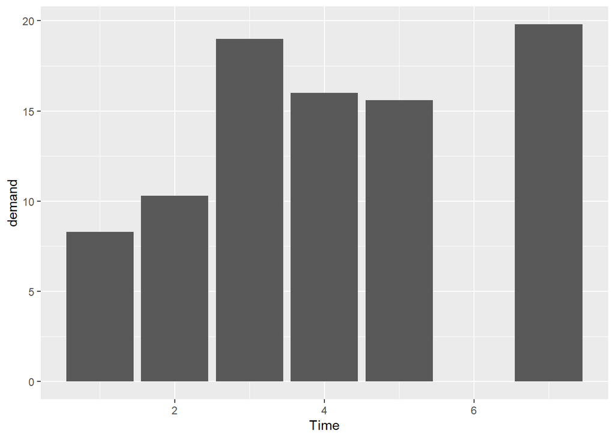

```r
ggplot(BOD, aes(x=Time, y=demand)) + geom_bar(stat="identity")
```

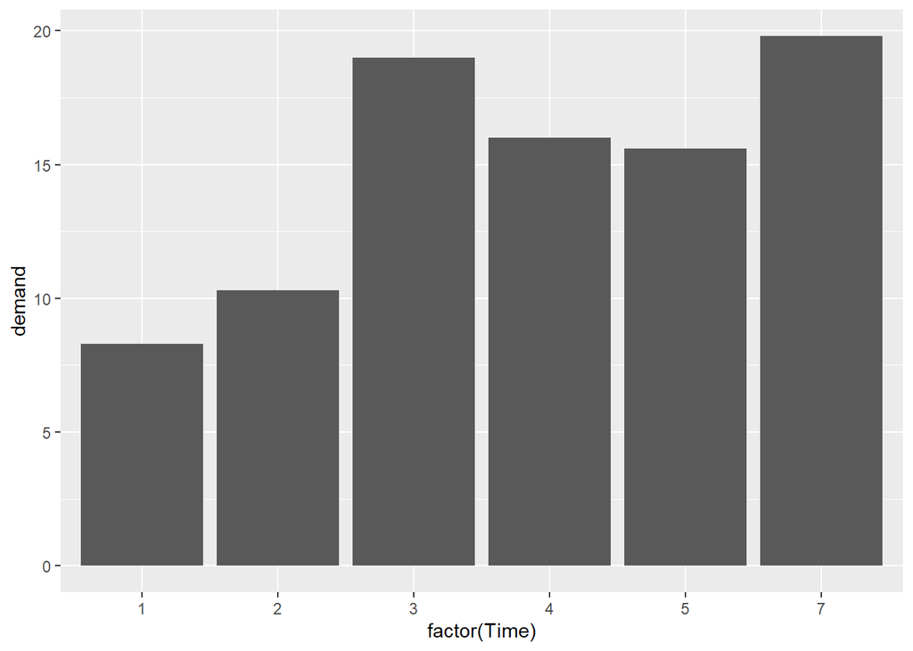

```r
# Convert Time to a discrete (categorical) variable with factor()
ggplot(BOD, aes(x=factor(Time), y=demand)) + geom_bar(stat="identity")
```

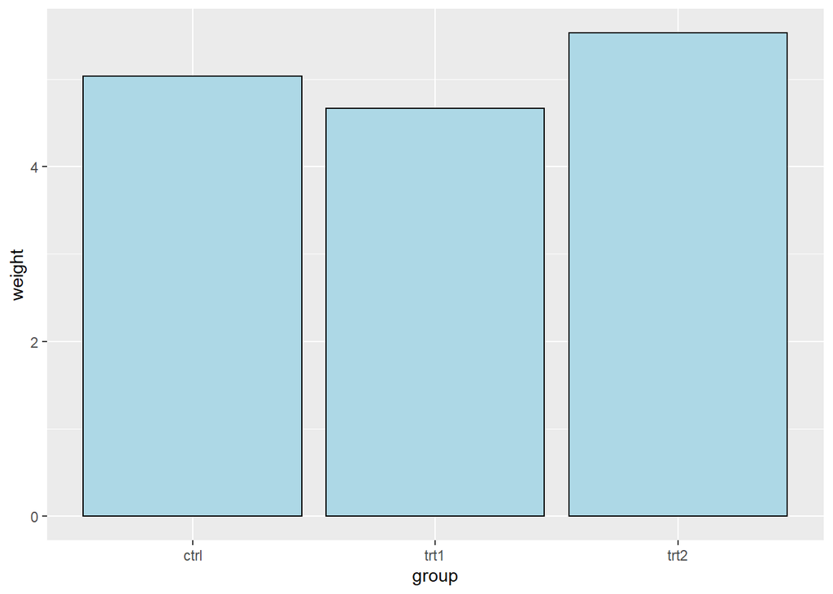

```r
ggplot(pg_mean, aes(x=group, y=weight)) +
geom_bar(stat="identity", fill="lightblue", colour="black")
```

```r
pg_mean
```

```
##   group weight
## 1  ctrl  5.032
## 2  trt1  4.661
## 3  trt2  5.526
```

```r
library(gcookbook) # For the data set
cabbage_exp
```

```
##   Cultivar Date Weight        sd  n         se
## 1      c39  d16   3.18 0.9566144 10 0.30250803
## 2      c39  d20   2.80 0.2788867 10 0.08819171
## 3      c39  d21   2.74 0.9834181 10 0.31098410
## 4      c52  d16   2.26 0.4452215 10 0.14079141
## 5      c52  d20   3.11 0.7908505 10 0.25008887
## 6      c52  d21   1.47 0.2110819 10 0.06674995
```

# 4 Sử dụng ggplot2 cho dữ liệu chuỗi thời gian

```r
library(ggplot2)
# Dữ liệu demo: economics trong gói ggplot2
head(economics)
```

```
## # A tibble: 6 x 6
##   date         pce    pop psavert uempmed unemploy
##   <date>     <dbl>  <dbl>   <dbl>   <dbl>    <dbl>
## 1 1967-07-01  507. 198712    12.6     4.5     2944
## 2 1967-08-01  510. 198911    12.6     4.7     2945
## 3 1967-09-01  516. 199113    11.9     4.6     2958
## 4 1967-10-01  512. 199311    12.9     4.9     3143
## 5 1967-11-01  517. 199498    12.8     4.7     3066
## 6 1967-12-01  525. 199657    11.8     4.8     3018
```

## 4.1 Tạo line plots cơ bản:

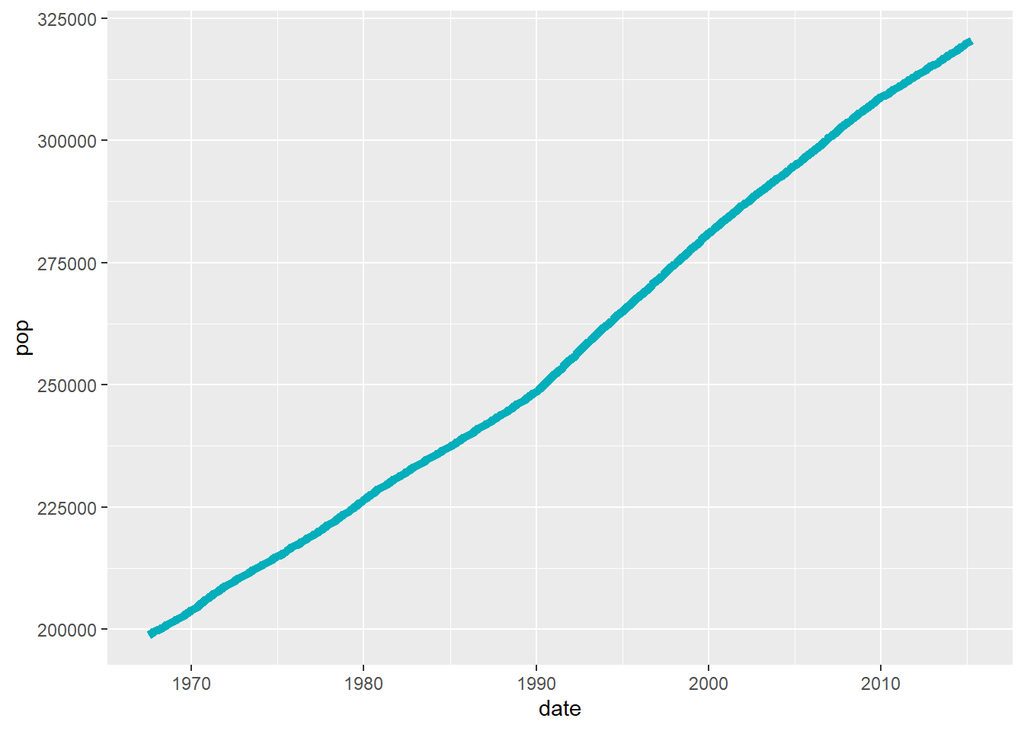

```r
# Basic line plot
ggplot(data = economics, aes(x = date, y = pop))+
  geom_line(color = "#00AFBB", size = 2)
```

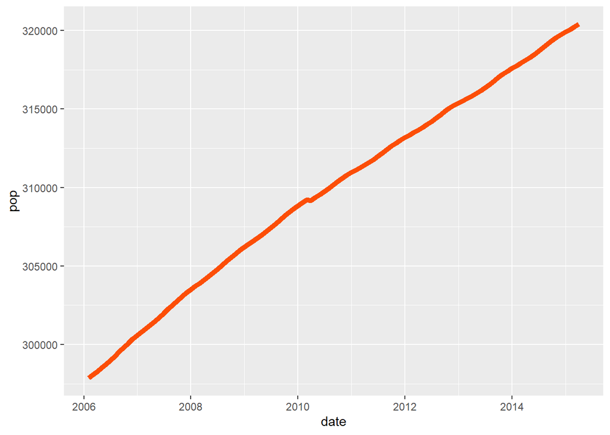

```r
# Plot a subset of the data
ss <- subset(economics, date > as.Date("2006-1-1"))
ggplot(data = ss, aes(x = date, y = pop)) +
  geom_line(color = "#FC4E07", size = 2)
```

## 4.2 Điều chỉnh kích thước line

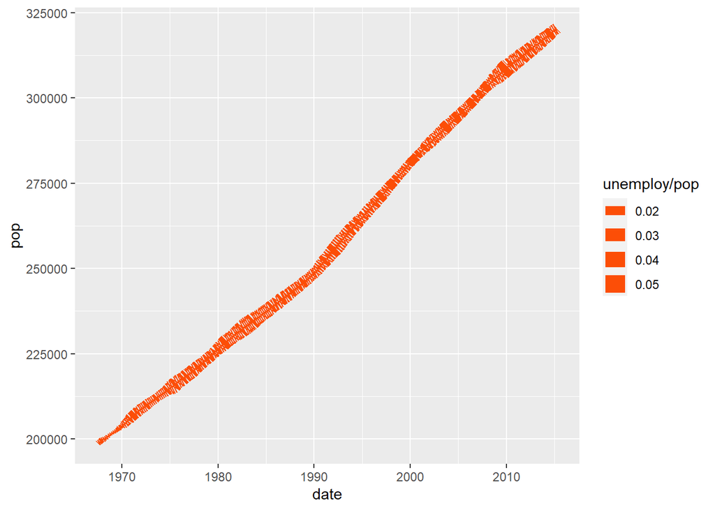

```r
ggplot(data = economics, aes(x = date, y = pop)) +
  geom_line(aes(size = unemploy/pop), color = "#FC4E07")
```

## 4.3 Tạo multiple time series plots

```r
# Để tạo multiple plot bởi 2 biến psavert và uempmed theo dates. Đầu tiên cần định hình lại data sửu dụng tidyr package
library(tidyr)
library(dplyr)
df <- economics %>%
  select(date, psavert, uempmed) %>%
  gather(key = "variable", value = "value", -date)
head(df, 3)
```

```
## # A tibble: 3 x 3
##   date       variable value
##   <date>     <chr>    <dbl>
## 1 1967-07-01 psavert   12.6
## 2 1967-08-01 psavert   12.6
## 3 1967-09-01 psavert   11.9
```

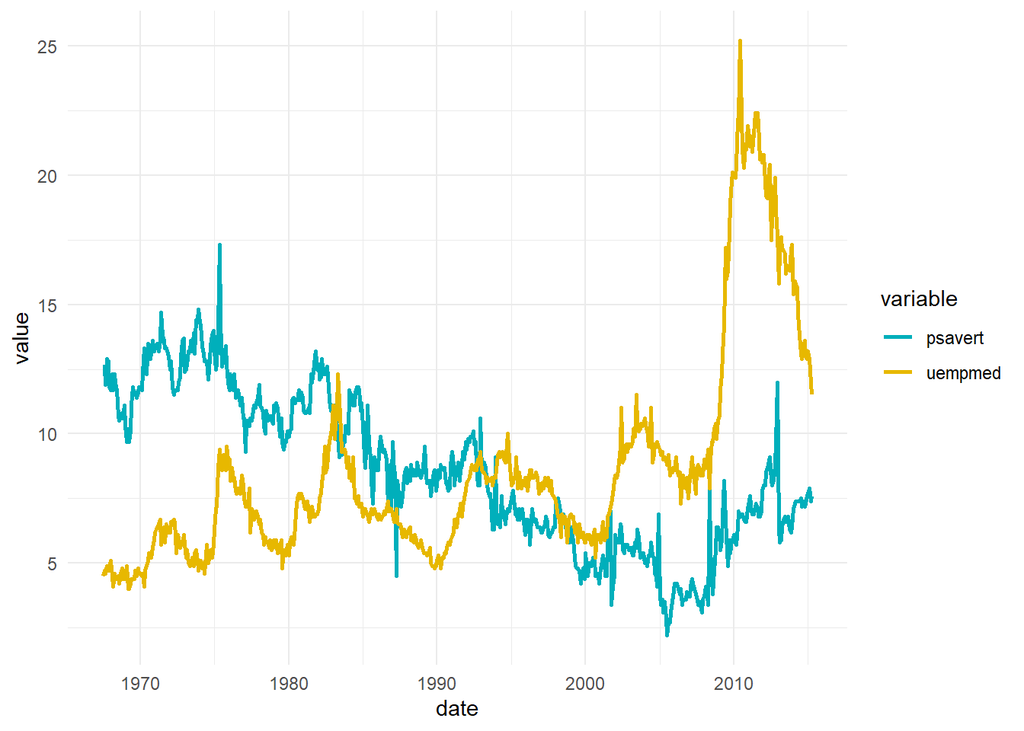

```r
# Multiple line plot
ggplot(df, aes(x = date, y = value)) +
  geom_line(aes(color = variable), size = 1) +
  scale_color_manual(values = c("#00AFBB", "#E7B800")) +
  theme_minimal()
```

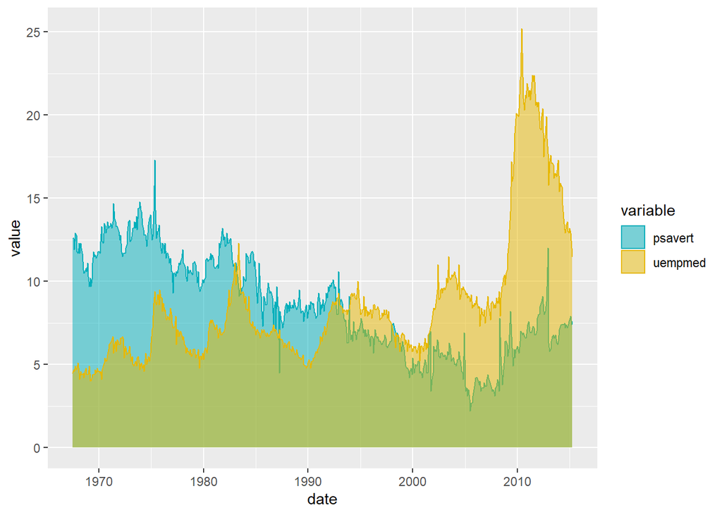

```r
# Area plot
ggplot(df, aes(x = date, y = value)) +
  geom_area(aes(color = variable, fill = variable),
            alpha = 0.5, position = position_dodge(0.8)) +
  scale_color_manual(values = c("#00AFBB", "#E7B800")) +
  scale_fill_manual(values = c("#00AFBB", "#E7B800"))
```

## 4.4 Set date axis limits

Key R function: scale_x_date()

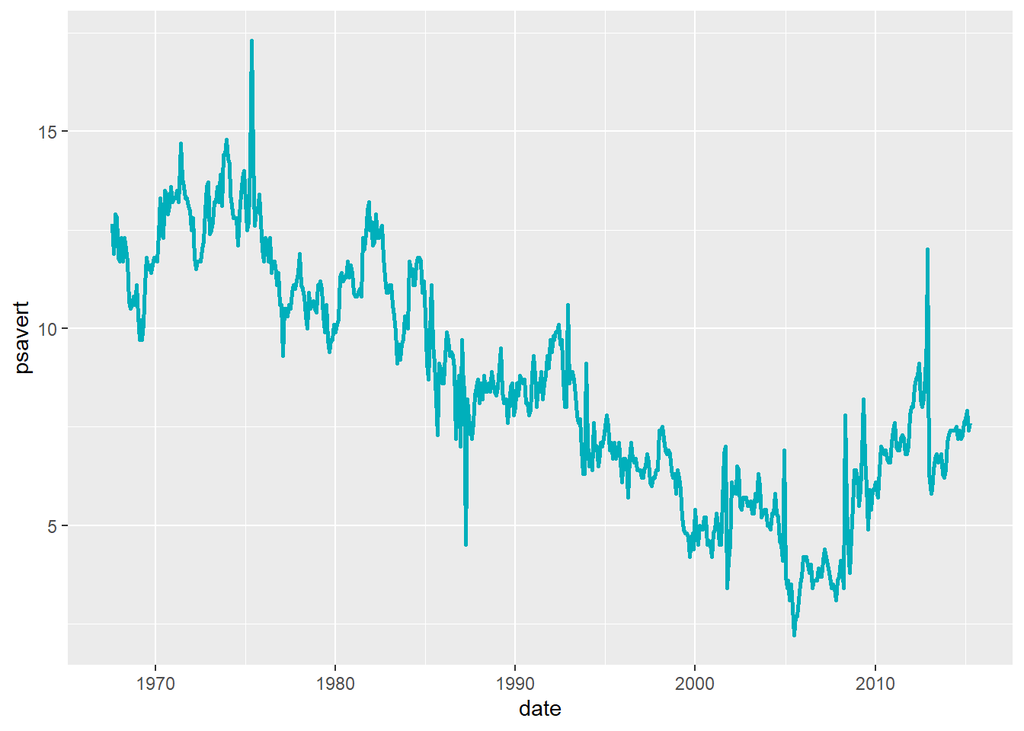

```r
# Base plot with date axis
p <- ggplot(data = economics, aes(x = date, y = psavert)) +
     geom_line(color = "#00AFBB", size = 1)
p
```

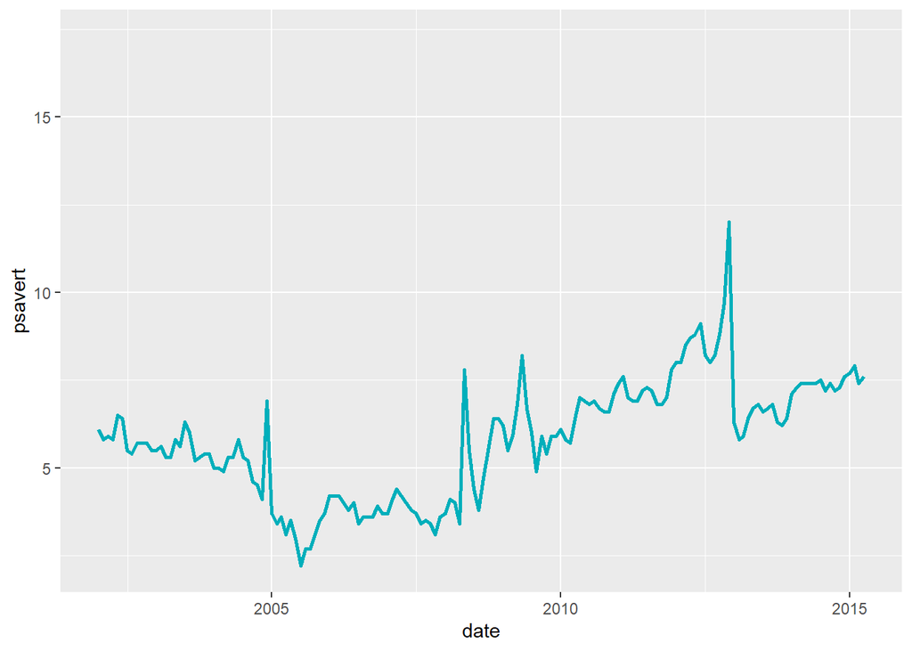

```r
# Set axis limits c(min, max)
min <- as.Date("2002-1-1")
max <- NA
p + scale_x_date(limits = c(min, max))
```

## 4.5 Định dạngt date axis labels

Key function: scale_x_date().

To format date axis labels, you can use different combinations of days, weeks, months and years:

- Weekday name: use %a and %A for abbreviated and full weekday name, respectively
- Month name: use %b and %B for abbreviated and full month name, respectively
- %d: day of the month as decimal number
- %Y: Year with century.
- See more options in the documentation of the function ?strptime

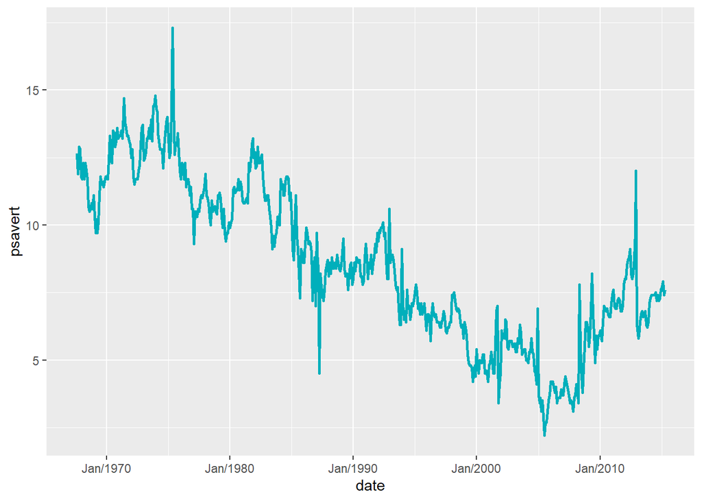

```r
# Format : month/year
p + scale_x_date(date_labels = "%b/%Y")
```

## 4.6 Add trend smoothed line

Key function: stat_smooth()

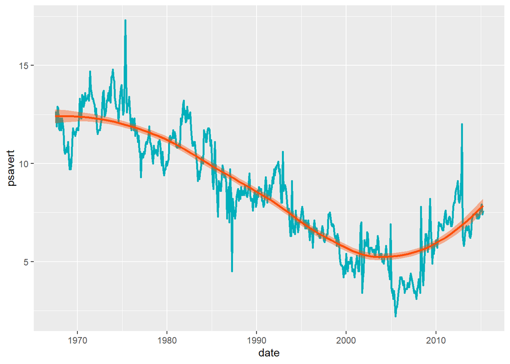

```r
p + stat_smooth(
  color = "#FC4E07", fill = "#FC4E07",
  method = "loess"
  )
```

## 4.7 ggplot2 mở rộng cho đối tượng ts

The ggfortify package is an extension to ggplot2 that makes it easy to plot time series objects (Horikoshi and Tang 2017). It can handle the output of many time series packages, including: zoo::zooreg(), xts::xts(), timeSeries::timSeries(), tseries::irts(), forecast::forecast(), vars:vars().

Another interesting package is the ggpmisc package (Aphalo 2017), which provides two useful methods for time series object:

- stat_peaks() finds at which x positions local y maxima are located, and
- stat_valleys() finds at which x positions local y minima are located.

Here, we’ll show how to easily:

- Visualize a time series object, using the data set AirPassengers (monthly airline passenger numbers 1949-1960).
- Identify shifts in mean and/or variance in a time series using the changepoint package.
- Detect jumps in a data using the strucchange package and the data set Nile (Measurements of the annual flow of the river Nile at Aswan).
- Detect peaks and valleys using the ggpmisc package and the data set lynx (Annual Canadian Lynx trappings 1821–1934).

First, install required R packages:

```r
install.packages(
  c("ggfortify", "changepoint",
    "strucchange", "ggpmisc")
)
```

Then use the autoplot.ts() function to visualize time series objects, as follow:

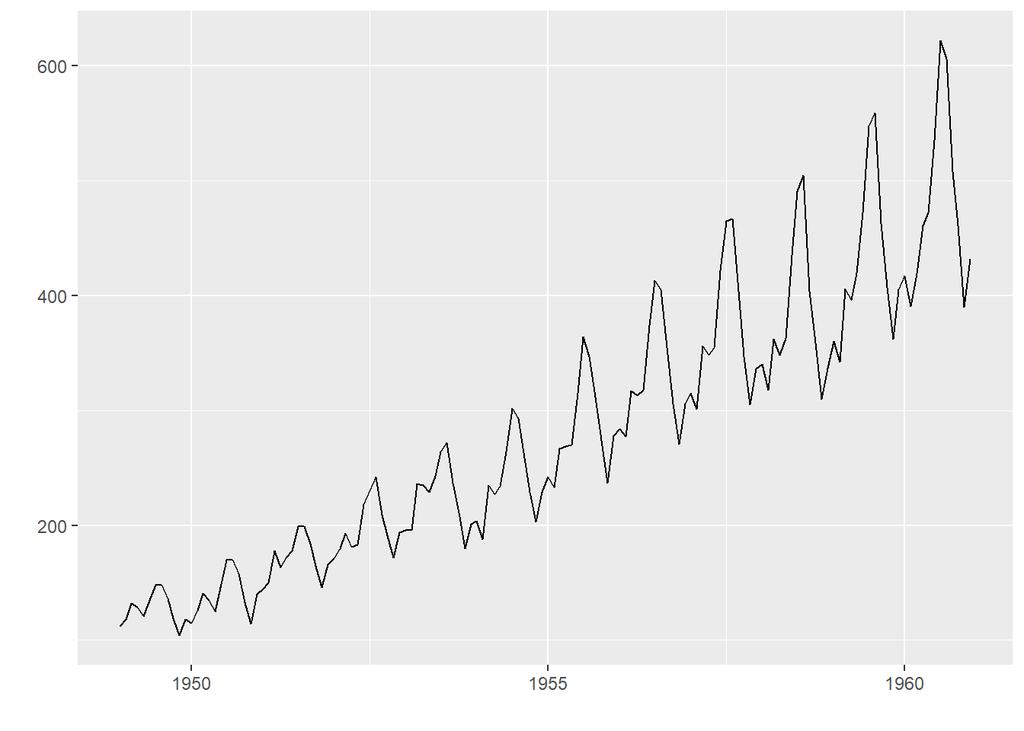

```r
library(ggfortify)
library(magrittr) # for piping %>%
# Plot ts objects
autoplot(AirPassengers)
```

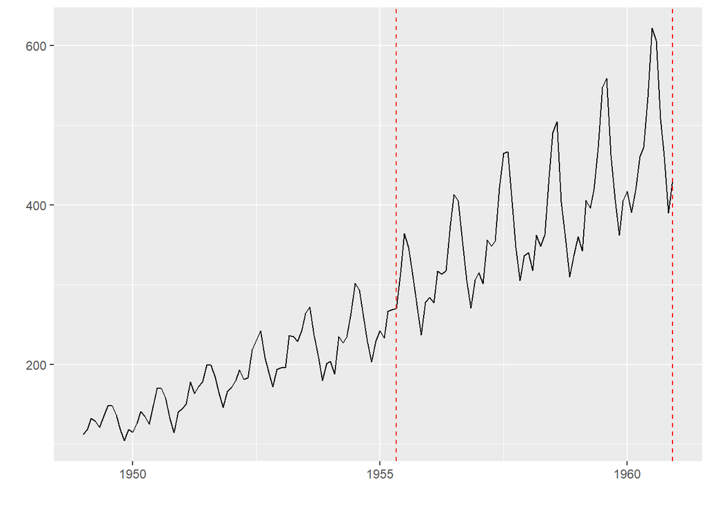

```r
# Identify change points in mean and variance
AirPassengers %>%
  changepoint:: cpt.meanvar() %>%  # Identify change points
  autoplot()
```

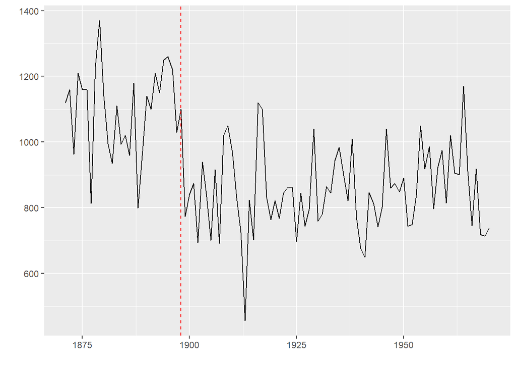

```r
# Detect jump in a data
strucchange::breakpoints(Nile ~ 1) %>%
  autoplot()
```

Detect peaks and valleys:

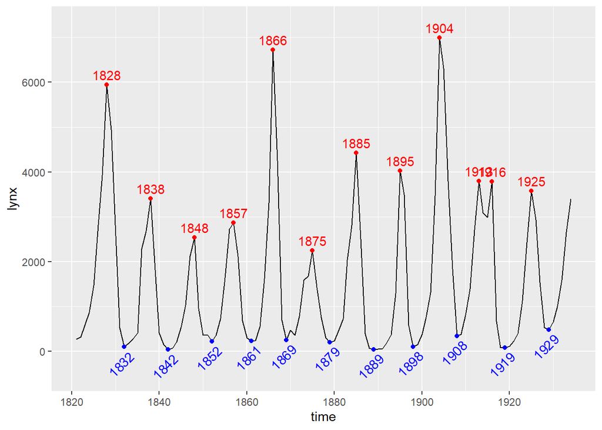

```r
library(ggpmisc)
ggplot(lynx, as.numeric = FALSE) + geom_line() +
  stat_peaks(colour = "red") +
  stat_peaks(geom = "text", colour = "red",
             vjust = -0.5, x.label.fmt = "%Y") +
  stat_valleys(colour = "blue") +
  stat_valleys(geom = "text", colour = "blue", angle = 45,
               vjust = 1.5, hjust = 1,  x.label.fmt = "%Y")+
  ylim(-500, 7300)
```

# 5 Sử dụng ggplot2 không cần code

Để sử dụng ggplot2 nhanh chóng mà không cần phải viết `code` trong R, các bạn cần tải gói `esquisse`:

```r
install.packages("esquisse")
```

Sau đó các bạn nạp gói `esquisse` và phiên làm việc của R và dùng hàm `esquisser()` để sử dụng ggplot2;

```r
library(esquisse)
esquisser()
```

Trên máy tính lúc này sẽ mở ra 1 cửa sổ mới để chúng ta có thể thực hiện các thao tác kéo thả như: import dữ liệu, chọn biến, trực quan hóa dữ liệu…Và thậm chí chúng ta có thể export phần script từ việc chúng ta trực quan hóa dữ liệu bằng việc kéo thả.

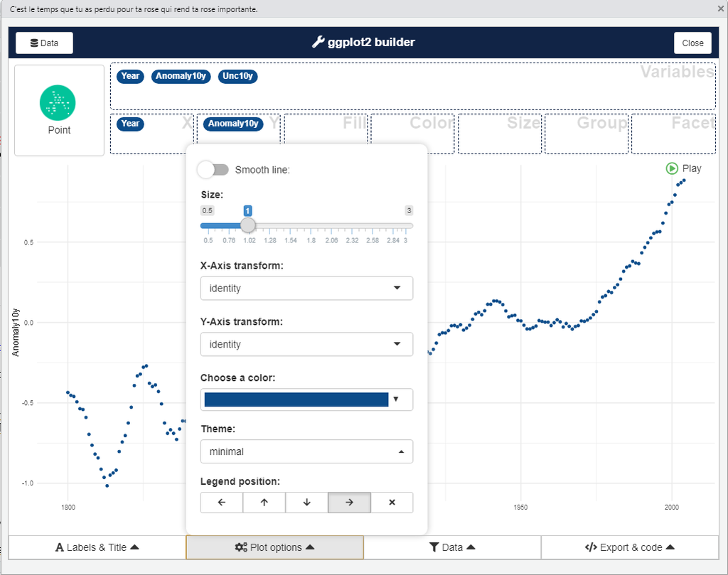

**Tài liệu tham khảo:**

http://www.sthda.com/english/articles/32-r-graphics-essentials/128-plot-time-series-data-using-ggplot/

Aphalo, Pedro J. 2017. Ggpmisc: Miscellaneous Extensions to ’Ggplot2’. https://CRAN.R-project.org/package=ggpmisc.

Horikoshi, Masaaki, and Yuan Tang. 2017. Ggfortify: Data Visualization Tools for Statistical Analysis Results. https://CRAN.R-project.org/package=ggfortify.